# 18-19. The Normal Distribution

## Preparatory work

Read: OpenIntro Statistics Section 4.1

## The Normal Distribution (bell curve)

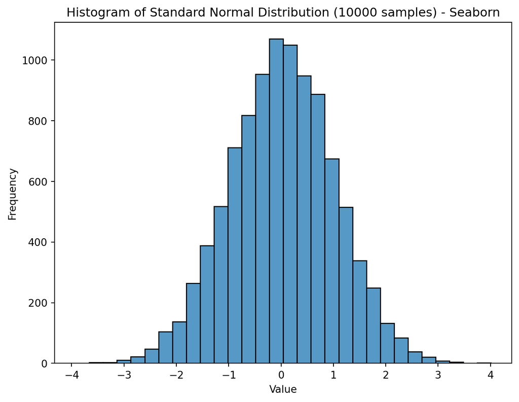

Figure 1: A standard normal distribution

### Normal Distribution is:

1. Shaped like a bell
2. Unimodal
3. Symmetric
4. Unskewedx

## The Normal Distribution is everywhere

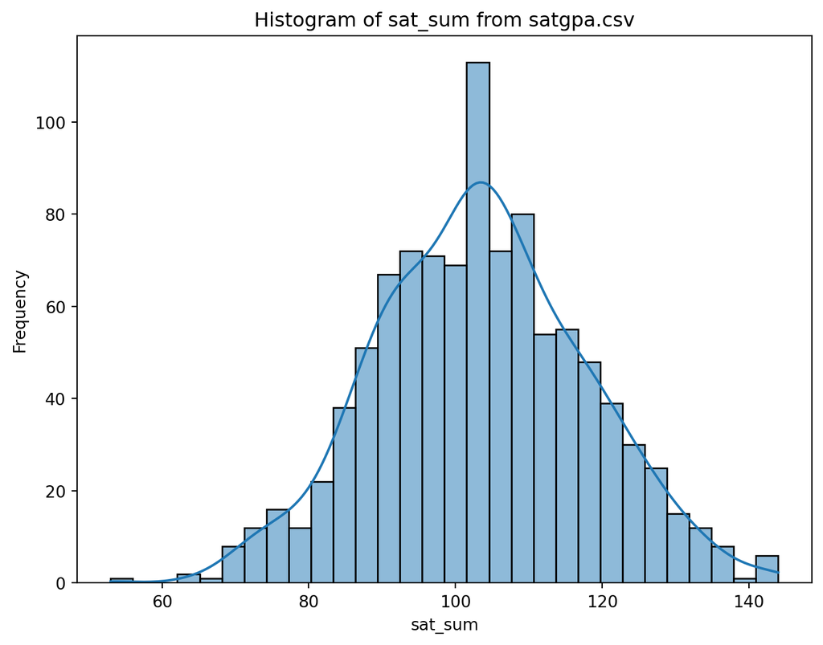

Figure 2: A suspiciously normal data distribution

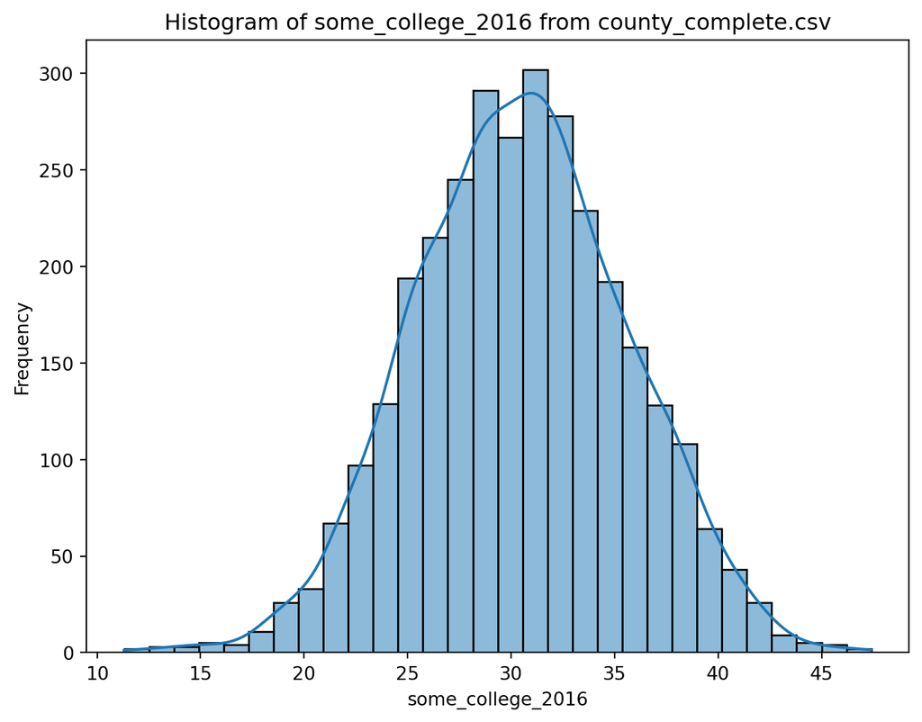

Figure 3: A suspiciously normal data distribution

## Plenty of data distributions are not normal

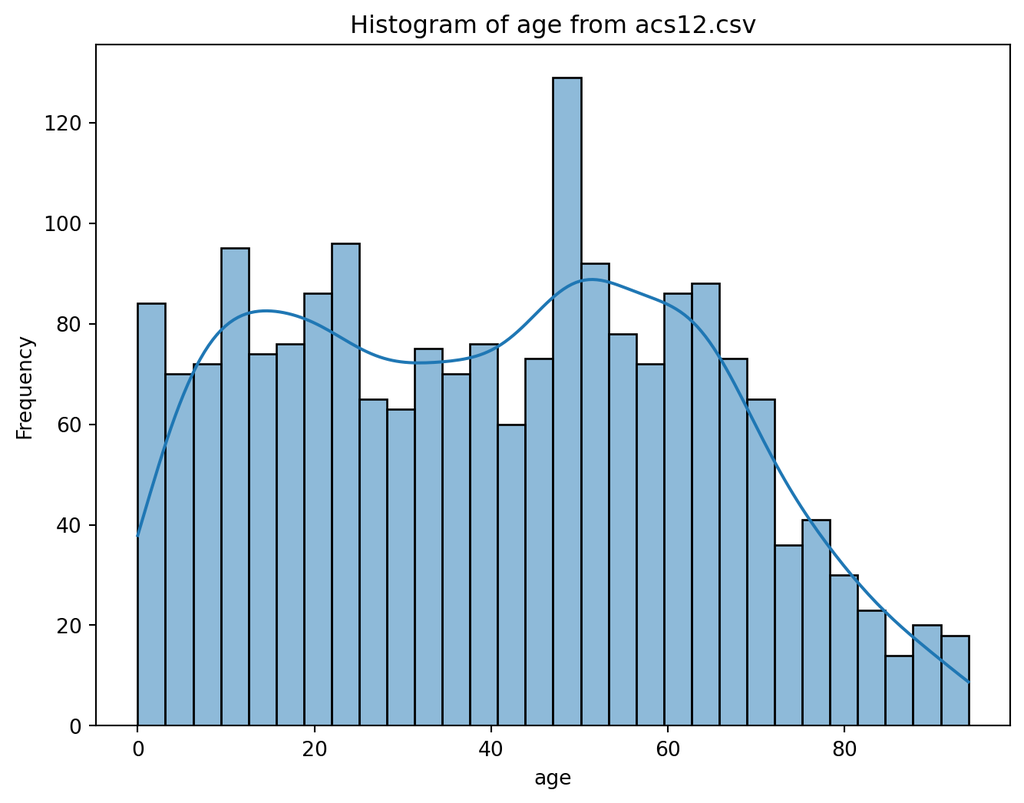

Figure 4: A far-from-normal data distribution

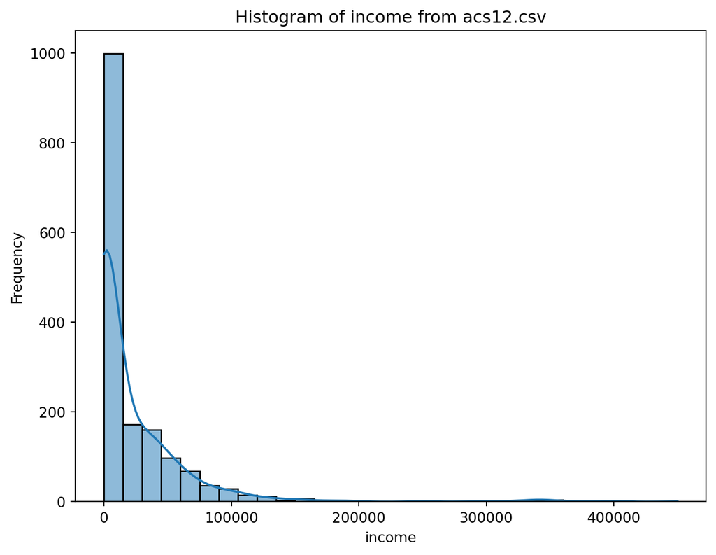

## The Family of Normal Distributions

[interactive chart not shown]

The notation $N(\mu, \sigma^2)$ refers to a normal distribution while telling its mean $\mu$ and its standard deviation $\sigma$. What kind of normal distribution is $N(100,16)$?

## Reading the bell curve

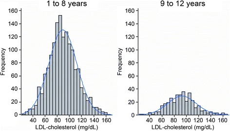

Cholesterol Level Histograms. Source: Slhessarenko, N., Jacob, C.M., Azevedo, R.S. et al. Serum lipids in Brazilian children and adolescents: determining their reference intervals. BMC Public Health 15, 18 (2015). https://doi.org/10.1186/s12889-015-1359-4. Open access article.

1. What is a typical cholesterol for a six year old?
2. What portion of kids age 1-8 have cholesterol between 60 and 120?
3. How unusual is a cholesterol of 160, for a kid aged 1-8?
4. Do kids age 1-8 have more, less, or about the same cholesterol, compared to kids 9-12?

## Technical definition, for the record

Technically, normal is not just unimodal, symmetric, unskewed, and bell shaped. A normal distribution fits the specific formula below. Lucky for us, we don’t need to use or memorize the formula in Math 125!

$$f(x) = \frac{1}{\sqrt{2\pi\sigma^2}} e^{-\frac{(x - \mu)^2}{2\sigma^2}}$$

## Central Limit Theorem

### When should we *expect* a distribution to be normal?

If a data variable aggregates many small independent effects, it’s usually normal or close. For example:

- Human height (arguably)
- Exam scores (usually)
- Cholesterol levels (usually)
- Game scores in sports (basketball more than hockey!)
- Sampling distributions (This is foreshadowing. More on this later!)

This phenomenon is called the Central Limit Theorem. Its precise statement is too technical for Math 125.

## Which are probably normal (or close)?

1. The widths of 2x4 lumber at Lowes.
2. The amount of liquid in coffee beverages served at Tim Hortons.
3. The weights of pets in Potsdam.
4. SAT scores of Potsdam High School graduates.
5. The lengths of days (throughout the year) in Potsdam.
6. The results of overlapping political polls, all taken at the same time and place (but polling different people).

## The empirical rule (68-95-99.7)

1. Within one standard deviation from the mean lies 68% of the data.
2. Within two standard deviations from the mean lies 95% of the data.
3. Within three standard deviations from the mean lies 99.7% of the data.

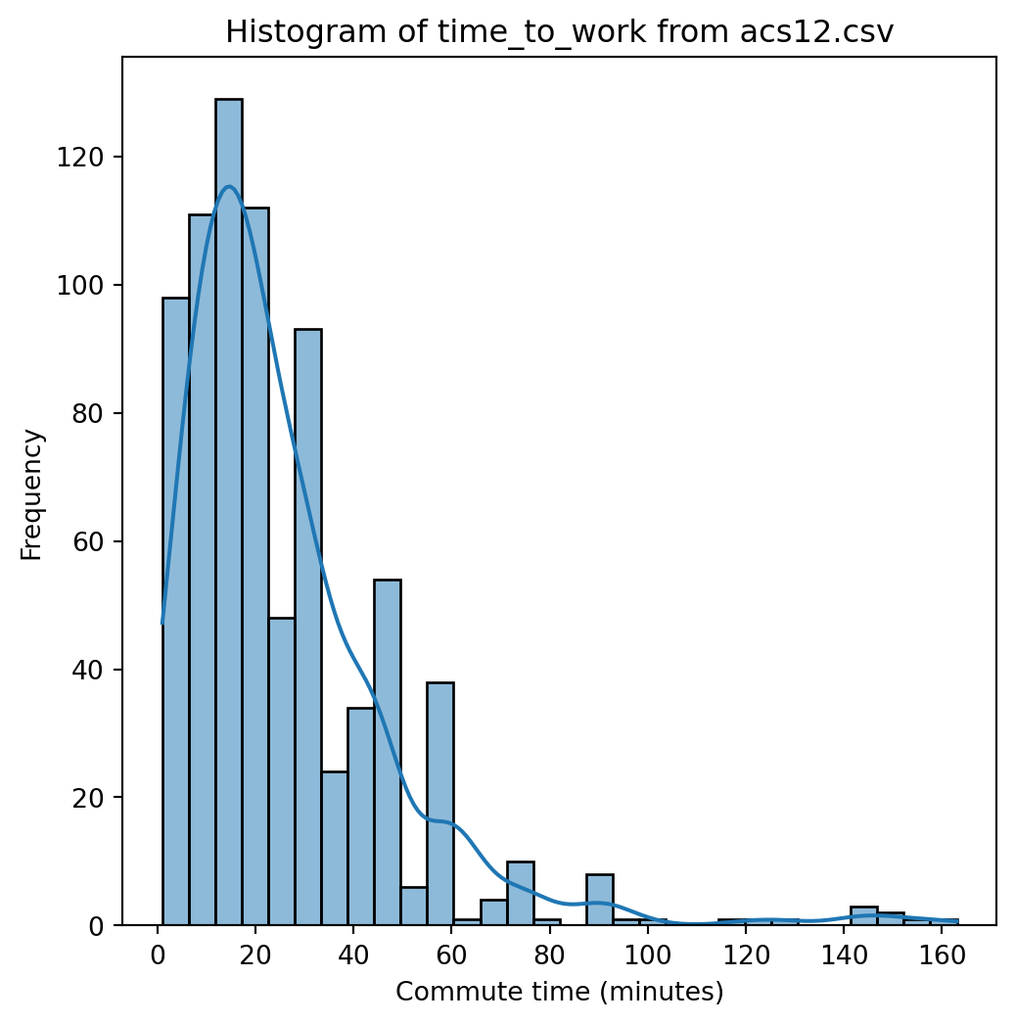

Figure 6: Time-to-work distribution

```
count    783.000000
mean      25.997446
std       22.290973
min        1.000000
25%       10.000000
50%       20.000000
75%       30.000000
max      163.000000
Name: time_to_work, dtype: float64
```

## The empirical rule (68-95-99.7)

Z-score Intro: So, is that a lot then? A certain pet parrot’s body temperature is 107°. What more would you need to know, before judging whether the body temperature is a health concern?

So, is that a lot then? A certain pet parrot’s body temperature is 107°. The average body temperature for the species is 105°. Of course, the parrot is 2° warmer than average. What other general stats about parrots and their temperatures would be useful to contextualize this information?

So, is that a lot then? A certain pet parrot’s body temperature is 107°. The average body temperature for the species is 105°. Of course, the parrot is 2° warmer than average. The standard deviation of body temp is 1.4°. Is the bird’s temperature normal, somewhat high, or very high? Why?

Judging relative to the distribution Judging a data value x relative to the distribution it’s in requires both: Comparison to the mean of the distribution: subtract μ Conversion to units of standard deviations: divide by σ Thus the formula: Z-score = (data value - μ) / σ The Z-score acts like a interchangeable standard of unusualness, scaled to the distribution the data belongs to.

Z-score = (value - μ) / σ It counts the number of standard deviations from the mean, which is a statistically “fair” across different distributions. Z = 0: Average. Z = +1, -1: Uninteresting. Z = +2, -2: Raise eyebrow. Z = +3, -3: Remarkable. Z = +5, -5: Stunning. Interpreting the Z-score

The rarity of a Z-score: the p-value A good measure of the unusualness of a Z-score is the portion of the curve at least as extreme as that score. Use Bognar’s tool to answer: How much of the normal distribution is above Z = 2.3? How much of the normal distribution is more extreme, on either side, than Z=3.1? Use stats.norm.cdf to answer: How much of the normal distribution is below Z = -5? How much of the normal distribution is above Z = 2.5?

Methods for finding p-value, recap To find tail areas, you can… Use the Empirical Rule with some geometric reasoning. (Z=1, 2, 3 only) Matt Bognar’s CDF calculator (Z in the range -4..4) Use Jupyter (Any Z will do) from scipy import stats stats.norm.cdf(2) Use a Z-table. (Paper method, limited accuracy and range)

Putting it all together Most people tend to score about 550 on a given exam, with a standard deviation of 60. Your score is 685. Good job! What is your Z-score? What is your percentile? An average business day sees about $1000 in sales, with a standard deviation of about $200. Sales were slow today. Only $450. What is the Z-score? How rare is such a disastrous sales day? A 1000-letter sample of English language should have on average about 80 “a”’s, with a standard deviation of about 9. A randomly chosen Youtube video description has 1000 characters but 120 “a”’s. What is the Z-score of this result? How rare is it? Can you think of alternate explanations?

Homework Solve homework problems “18-19. The Normal Distribution”